# Who is faster up and down

Carlos Campos

Fall 2018

# Introduction

Q3. differences between time up and down the stairs between guys and gals. In the next set of data, we will decide if $H_0$ the time for guys and gals going up and down the stairs is the same.

We start by loading the data into 2 data frames

```r
library(readr)
Sec02 <- read_csv("Class_Survey_Sec02.csv")
Sec23 <- read_csv("Class_Survey_Sec23.csv")
Sec02 <- mutate(Sec02,sect="PM")
Sec23 <- mutate(Sec23,sect="Eve")
alldat <- bind_rows(Sec02,Sec23)
```

```r
write.csv(x=alldat,file="alldat.csv")
```

# Methods

we use graphical dscriptions suchs as a box plot and numerical summaries.

# Results

the different tests conducted show a sligth difference between gays and gals going up the stairs. Gays go up and down slighly faster than gals with 6 seconds in differences (gals 30-24 guys).

## Descriptive Results

### Graphical Descriptive Results

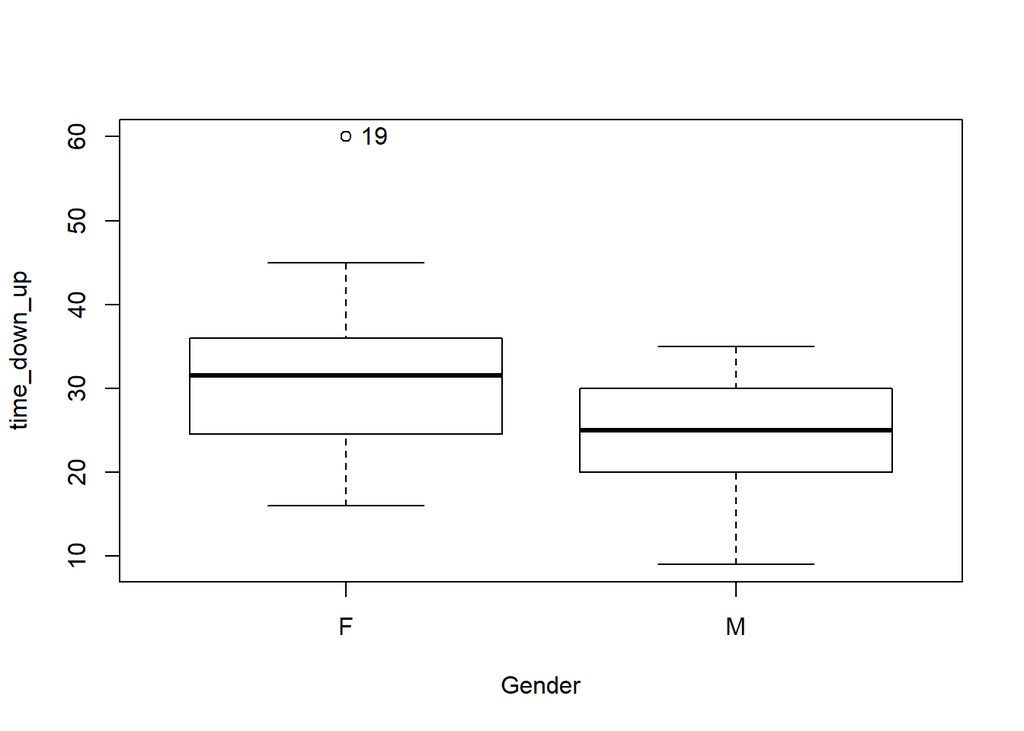

```
## [1] "19"
```

```r
Boxplot(time_down_up~Gender, data=alldat, id=list(method="y"))
```

### Numerical Descriptive Results

```r
numSummary(alldat[,"time_down_up", drop=FALSE], groups=alldat$Gender,
  statistics=c("mean", "sd", "IQR", "quantiles"), quantiles=c(0,.25,.5,.75,1))
```

```
##       mean       sd   IQR 0%   25%  50% 75% 100% time_down_up:n
## F 30.64286 9.810102 11.25 16 24.75 31.5  36   60             28
## M 24.05000 7.451422 10.00  9 20.00 25.0  30   35             20
##   time_down_up:NA
## F               3
## M               3
```

## Inferential Results

We will run a t-test to test this hypothesis.

$H_0$ The average time to go up and down the stairs is the same between guys and gals.  
$H_a$ The average time is different between guys and gals in going up and down the stairs.

```r
t.test(time_down_up~Gender, alternative='two.sided', conf.level=.95, var.equal=FALSE,
  data=alldat)
```

```
##
##  Welch Two Sample t-test
##
## data:  time_down_up by Gender
## t = 2.6449, df = 45.785, p-value = 0.01116
## alternative hypothesis: true difference in means is not equal to 0
## 95 percent confidence interval:
##   1.574794 11.610920
## sample estimates:
## mean in group F mean in group M
##        30.64286        24.05000
```

```r
a <- na.omit(alldat$time_down_up[ which(alldat$Gender=='F')])
b <- na.omit(alldat$time_down_up[ which(alldat$Gender=='M')])
bs=bootstrp (a,b,1000)
```

```
## Difference was  6.592857
##  probability of observing =  0.016
```

# Discussion and Conclusion

there’s a difference in time between guys and gals going up and down the stairs the p value=0.01116 shows significance and the Hyphotesis; $H_0$ The average time to go up and down the stairs is the same between guys and gals is rejected. in conculsion, the data use in the different test shows a difference between guys and gals going up and down the stairs guys having an avarage peiod time of 24 seconds and gals and having an avarage perido time of 30 seconds up and down the stairs.